# Cyclistic Analysis Workflow Using R

Dongli Liu

2023-09-08

## INTRODUCTION

### Usage

> To recurrent this case studay:
- pull [repository](https://github.com/Dongli99/Cyclistic.git)
- download [dataset](https://centennialcollegeedu-my.sharepoint.com/:u:/g/personal/dliu99_my_centennialcollege_ca/EebPZIYzXXZAr0xgrzCrjkMBBJ1KGVEqkI1mHfyY7_SEqA?e=YmxcDV)
- extract tripdata/ to Cyclistic/
- run Cyclistic_Analysis_Markdown_R.Rmd in RStudio
- expect long-time running due to large dataset.

> How to use

```r
print("This is a normal code chunk.")
```

```r
print("This is a reusable code chunk.")
```

### Overview

This project focuses on the completion of the [Google Data Analytics Professional Certificate](https://www.coursera.org/professional-certificates/google-data-analytics?) case study. The case study involved real-world data analysis tasks within a fictional company, Cyclistic, a bike-share program operating in Chicago. The goal was to analyze data, answer critical business questions, and make data-driven recommendations to maximize annual memberships.

### Process

The project followed a structured data analysis process:

- *Ask*: Defined key business questions and objectives.
- *Prepare*: Gathered and cleaned the data from various sources.
- *Process*: Performed data manipulation and transformation for analysis.
- *Analyze*: Conducted in-depth analysis to uncover insights.
- *Share*: Communicated findings through visualizations and reports.
- *Act*: Presented recommendations based on data insights.

### Principles

- *Reusability*: Creating and collecting reusable modules for future applications.
- *Optimization*: Continuously enhancing modules through study and work.
- *Structured Organization*: Implementing an organized framework for knowledge and tools.
- *Thoroughness*: Trying to cover the whole learning processes in this report.
- *Automation*: Streamlining processes through automation, regardless of current complexity.
- *Efficiency*: maintaining a clutter-free workspace including the removal of unnecessary objects.

### Tools

- *R Studio*: Main tool to clean, analyze, visualize data.
- *Excel*: Prepare data as .csv files.
- *Python*: Automating download of multiple .zip files.
- *VS Code*: Editing Python file, maintaining files.
- *Git*: Syncing the process to Github.
- *ChatGPT*: Answering technical questions quickly.
- *Stackoverflow*: Searching technical questions.

## ASK

- *Business Objective*: Cyclistic aimed to increase annual memberships and understand the differences in bike usage between annual members and casual riders.
- *Key Questions*: Three guiding questions drove the analysis:
  - How do annual members and casual riders use Cyclistic bikes differently?
  - Why would casual riders buy Cyclistic annual memberships?
  - How can Cyclistic use digital media to influence casual riders to become members?

## PREPARE

### Data Source

The data are downloaded from [divvy](https://divvy-tripdata.s3.amazonaws.com/index.html) which is introduced by Coursera and Google. To download multiple files automatically, the [mutidownloader Python app](https://github.com/Dongli99/MultiDownloader.git) was developed under the assistant of ChatGPT. This case study selects the subset of the data (2020Q1-202307).

> Data Overview
- data size: 3.3G
- num of files: 41
- num of columns: 13
- num of rows: 17,962,572

### Enviorment Prepare

```r
install.packages("tidyverse")
library(tidyverse)
library(skimr)
```

### Data Prepare

> Set data path and file list.

```r
data_path <- "./tripdata"
csv_files <- list.files(data_path, pattern = "\\.csv", full.names = TRUE)
```

> Check col name consistency.

```r
check_column_consistency <- function(csv_files, std_cols) {
  inconsistent <- FALSE
  err_list <- character(0)
  for (file in csv_files){
    this_cols = colnames(read.csv(file))
    err_count = 0
    for (i in seq_along(this_cols)){
      if (this_cols[i] != std_cols[i]){
        err_list <- c(err_list, paste(file , "-" , this_cols[i]), " should be ", std_cols[i])
        err_count <- err_count + 1
        inconsistent <- TRUE
      }
    }
  }
  if (!inconsistent){
    print("The colnames are consistent")
  } else {
    print("WARNING - inconsistent cols:")
    print(paste(err_list, collapse = "\n"))
  }
}
std_cols <- colnames(read.csv(csv_files[1]))
check_column_consistency(csv_files, std_cols)
```

```
## [1] "The colnames are consistent"
```

> Combine .csv files into tibble

```r
combine_csvs_to_tibble <- function(csv_files){
  tb = tibble() # declare an empty tibble
  for (file in csv_files){ # loop the path to rbind files to tb
    f <- read.csv(file)
    tb <- rbind(tb, f)
  }
  return(tb)
}
tb <- combine_csvs_to_tibble(csv_files)
```

## PROCESS

### Inspect data

```r
skim_without_charts(tb)
```

Data summary

| Name | tb |
| --- | --- |
| Number of rows | 17962572 |
| Number of columns | 13 |
| _______________________ |  |
| Column type frequency: |  |
| character | 9 |
| numeric | 4 |
| ________________________ |  |
| Group variables | None |

**Variable type: character**

| skim_variable | n_missing | complete_rate | min | max | empty | n_unique | whitespace |
| --- | --- | --- | --- | --- | --- | --- | --- |
| ride_id | 0 | 1.00 | 8 | 16 | 0 | 17962352 | 0 |
| rideable_type | 0 | 1.00 | 11 | 13 | 0 | 3 | 0 |
| started_at | 0 | 1.00 | 15 | 19 | 0 | 14507283 | 0 |
| ended_at | 0 | 1.00 | 15 | 19 | 0 | 14513167 | 0 |
| start_station_name | 0 | 1.00 | 0 | 64 | 2098889 | 2002 | 0 |
| start_station_id | 83583 | 1.00 | 0 | 44 | 2016061 | 1858 | 0 |
| end_station_name | 0 | 1.00 | 0 | 64 | 2254060 | 2018 | 0 |
| end_station_id | 98105 | 0.99 | 0 | 44 | 2156557 | 1860 | 0 |
| member_casual | 0 | 1.00 | 6 | 6 | 0 | 2 | 0 |

**Variable type: numeric**

| skim_variable | n_missing | complete_rate | mean | sd | p0 | p25 | p50 | p75 | p100 |
| --- | --- | --- | --- | --- | --- | --- | --- | --- | --- |
| start_lat | 0 | 1 | 41.90 | 0.05 | 41.64 | 41.88 | 41.90 | 41.93 | 45.64 |
| start_lng | 0 | 1 | -87.65 | 0.03 | -87.92 | -87.66 | -87.64 | -87.63 | -73.80 |
| end_lat | 18598 | 1 | 41.90 | 0.06 | 0.00 | 41.88 | 41.90 | 41.93 | 42.37 |
| end_lng | 18598 | 1 | -87.65 | 0.07 | -88.97 | -87.66 | -87.64 | -87.63 | 0.00 |

### Transform Format

> Date Converting function

```r
convert_datetime <- function(column) {
  candidates <- c("%Y-%m-%d %H:%M:%S", "%Y-%m-%d %H:%M", "%d/%m/%Y %H:%M:%S", "%m/%d/%Y %H:%M:%S")
  out <- as.POSIXct(column, format = candidates[1])
  for (fmt in candidates[-1]) {
    if (!any(is.na(out))) break
    out[is.na(out)] <- as.POSIXct(column[is.na(out)], format = fmt)
  }
  return(out)
}
```

- Traditional way will miss at least 50% values due to the variety of date formats.
- This solution was inspired by [r2evans](https://stackoverflow.com/questions/70304425/r-datetime-series-missing-values)

> Mutate Data Types

```r
tb <- tb %>%
  mutate(
    start_station_id = as.factor(start_station_id),
    end_station_id = as.factor(end_station_id),
    start_station_name = as.factor(start_station_name),
    end_station_name = as.factor(end_station_name),
    rideable_type = as.factor(rideable_type),
    member_casual = as.factor(member_casual),
    ended_at = convert_datetime(ended_at),
    started_at = convert_datetime(started_at)
  )
```

### Improve Quality

> Trim abnormal Observations

```r
tb <- tb %>%
  filter(
    !is.na(start_station_id) &
      !is.na(end_station_id) &
      !is.na(end_lat) &
      !is.na(end_lng) &
      started_at < ended_at
    )
```

- less than 1% abnormal data were deleted

> Inspect geographic variable
- station_id, station_name, and lat&lng are three interchangeable geographic metrics
- This task is to select and optimize one geographic data for future analysis

```r
station_list <- tb %>%
  select(start_station_id, start_station_name) %>%
  group_by(start_station_id, start_station_name) %>%
  summarize(n = n(), .groups = 'drop') %>%
  arrange(start_station_name)
station_list %>%
  filter(start_station_name == "")
```

```
## # A tibble: 4 × 3
##   start_station_id start_station_name       n
##   <fct>            <fct>                <int>
## 1 ""               ""                 2015740
## 2 "13221"          ""                       1
## 3 "20215"          ""                       1
## 4 "WL-008"         ""                       1
```

- 11.3% (2015743) rows have empty station id & name.
- Seeking probability of alternatively using lng & lat.

```r
lat_lng_list <- tb %>%
  mutate(
    start_lat = round(start_lat, digits = 3),
    start_lng = round(start_lng, digits = 3),
    end_lat = round(end_lat, digits = 3),
    end_lng = round(end_lng, digits = 3)# str(lat_lng_list)
  ) %>%
  select(start_lat, start_lng) %>%
  group_by(start_lat, start_lng) %>%
  summarize(n = n(), .groups = 'drop') %>%
  arrange(start_lat)
str(lat_lng_list)
```

```
## tibble [4,878 × 3] (S3: tbl_df/tbl/data.frame)
##  $ start_lat: num [1:4878] 41.6 41.6 41.6 41.6 41.6 ...
##  $ start_lng: num [1:4878] -87.7 -87.6 -87.6 -87.5 -87.5 ...
##  $ n        : int [1:4878] 1 2 1 4 2 278 1 1 108 10 ...
```

- according to the number of rows `digit=2: 749; digit=3: 4878`, lat&lng is not good representative.
- Before using station name, check the distribution of empty name.

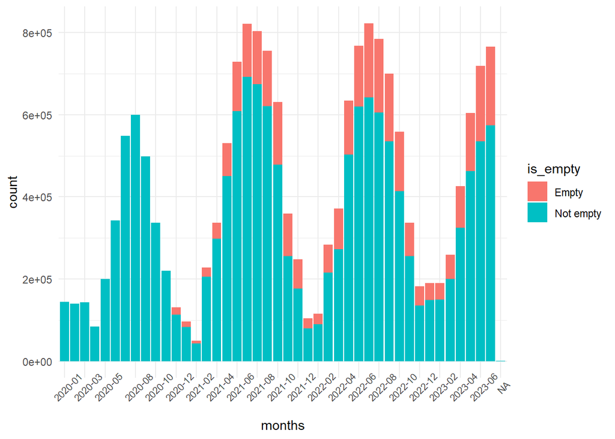

```r
empty_value_monthly <- function(tb, date_col, col_to_check1, col_to_check2){
  empty_list <- tb %>%
  mutate(
    months = format(ymd_hms(.data[[date_col]]), "%Y-%m"),
    is_empty = ifelse(
      .data[[col_to_check1]]=="" | .data[[col_to_check2]]=="",
      "Empty",
      "Not empty"
      )
  )
  ggplot(data = empty_list)+
    geom_bar(mapping = aes(x = months, fill = is_empty))+
    theme_minimal()+
    theme(axis.text.x = element_text(angle = 45, size = 8))+
    scale_x_discrete(breaks = unique(empty_list$months)[c(TRUE, FALSE)])
}
empty_value_monthly(tb, "started_at", "start_station_name", "end_station_name")
```

```r
tb <- tb %>%
  filter(start_station_name != "" & end_station_name != "")
```

### Refine

> Rearrange columns
- remove unnecessary cols.
- add useful cols for further analysis.

```r
trips <- tb %>%
  select(ride_id, rideable_type, started_at, ended_at, start_station_name, end_station_name, member_casual) %>%
  mutate(
    duration = as.integer((ended_at - started_at)/60),
    weekday = as.factor(weekdays(started_at))
  ) %>%
  mutate(
    is_weekend = ifelse(weekday %in% c("Saturday", "Sunday"), TRUE, FALSE)
  )
glimpse(trips)
```

```
## Rows: 14,722,329
## Columns: 10
## $ ride_id            <chr> "EACB19130B0CDA4A", "8FED874C809DC021", "789F3C21E4…
## $ rideable_type      <fct> docked_bike, docked_bike, docked_bike, docked_bike,…
## $ started_at         <dttm> 2020-01-21 20:06:59, 2020-01-30 14:22:39, 2020-01-…
## $ ended_at           <dttm> 2020-01-21 20:14:30, 2020-01-30 14:26:22, 2020-01-…
## $ start_station_name <fct> Western Ave & Leland Ave, Clark St & Montrose Ave, …
## $ end_station_name   <fct> Clark St & Leland Ave, Southport Ave & Irving Park …
## $ member_casual      <fct> member, member, member, member, member, member, mem…
## $ duration           <int> 7, 3, 2, 8, 5, 4, 4, 4, 4, 3, 3, 6, 8, 7, 16, 35, 3…
## $ weekday            <fct> Tuesday, Thursday, Thursday, Monday, Thursday, Frid…
## $ is_weekend         <lgl> FALSE, FALSE, FALSE, FALSE, FALSE, FALSE, FALSE, FA…
```

## Analyze

### Group Summary

> In-depth comparable summary
- some insights can be detected by this function

```r
comparable_summaries <- function(df, col, groups){
  summary = data.frame()
  for (i in seq_along(groups)) {
    group_skim <- df %>%
      filter(.data[[col]] == groups[i]) %>%
      skim() %>%
      mutate(
        group = groups[i]
      ) %>%
      as_tibble()
    summary <- rbind(summary, group_skim)
  }
  sum <- df %>%
    filter(.data[[col]] %in% groups) %>%
    group_by(.data[[col]]) %>%
    summarize(
      n_rows = n(),
      percentage = n_rows / nrow(df) * 100
        ) %>%
    print()
  print("------------------------------------------------------------------")
  nm_summary <- summary %>%
    filter(!is.na(numeric.mean)) %>%
    select(var = skim_variable, group, min = numeric.p0, max = numeric.p100, median = numeric.p50, mean = numeric.mean) %>%
    group_by(var) %>%
    print()
  print("------------------------------------------------------------------")
  chr_summary <- summary %>%
    filter(!is.na(character.n_unique)) %>%
    select(var = skim_variable, group, unique_values = character.n_unique) %>%
    group_by(var) %>%
    print()
  print("------------------------------------------------------------------")
  fct_summary <- summary %>%
    filter(!is.na(factor.top_counts)) %>%
    select(var = skim_variable, group, count = factor.top_counts) %>%
    group_by(var) %>%
    print()
  print("------------------------------------------------------------------")
  lgc_summary <- summary %>%
    filter(!is.na(logical.count)) %>%
    select(var = skim_variable, group, count = logical.count) %>%
    group_by(var) %>%
    print()
}
comparable_summaries(trips, "member_casual", c("member", "casual"))
```

```
## # A tibble: 2 × 3
##   member_casual  n_rows percentage
##   <fct>           <int>      <dbl>
## 1 casual        5962323       40.5
## 2 member        8760006       59.5
## [1] "------------------------------------------------------------------"
## # A tibble: 2 × 6
## # Groups:   var [1]
##   var      group    min    max median  mean
##   <chr>    <chr>  <dbl>  <dbl>  <dbl> <dbl>
## 1 duration member     0  93733      9  12.9
## 2 duration casual     0 156390     16  31.6
## [1] "------------------------------------------------------------------"
## # A tibble: 2 × 3
## # Groups:   var [1]
##   var     group  unique_values
##   <chr>   <chr>          <int>
## 1 ride_id member       8760001
## 2 ride_id casual       5962321
## [1] "------------------------------------------------------------------"
## # A tibble: 10 × 3
## # Groups:   var [5]
##    var                group  count
##    <chr>              <chr>  <chr>
##  1 rideable_type      member cla: 4700220, ele: 2253060, doc: 1806726
##  2 start_station_name member Cla: 77379, Kin: 76052, Wel: 68552, Wel: 61476
##  3 end_station_name   member Cla: 78247, Kin: 76207, Wel: 70665, Wel: 61417
##  4 member_casual      member mem: 8760006, cas: 0
##  5 weekday            member Wed: 1367576, Thu: 1350442, Tue: 1343498, Fri: 125…
##  6 rideable_type      casual cla: 2609785, doc: 1686702, ele: 1665836
##  7 start_station_name casual Str: 170468, Mil: 85499, Mic: 77909, DuS: 62406
##  8 end_station_name   casual Str: 181501, Mil: 91088, Mic: 82684, The: 67554
##  9 member_casual      casual cas: 5962323, mem: 0
## 10 weekday            casual Sat: 1310343, Sun: 1091226, Fri: 856284, Thu: 7193…
## [1] "------------------------------------------------------------------"
## # A tibble: 2 × 3
## # Groups:   var [1]
##   var        group  count
##   <chr>      <chr>  <chr>
## 1 is_weekend member FAL: 6539053, TRU: 2220953
## 2 is_weekend casual FAL: 3560754, TRU: 2401569
```